# THE ICONIC - Tech Evaluation Modelling Response

#### Order Logistics Related

High correlations: - Returns and orders - Vouchers and orders - Returns and vouchers

```r
X1<-df7_c[,c("orders","orders_pm","cancels","returns","different_addresses",
          "shipping_addresses","devices","vouchers","infer_male")]
```

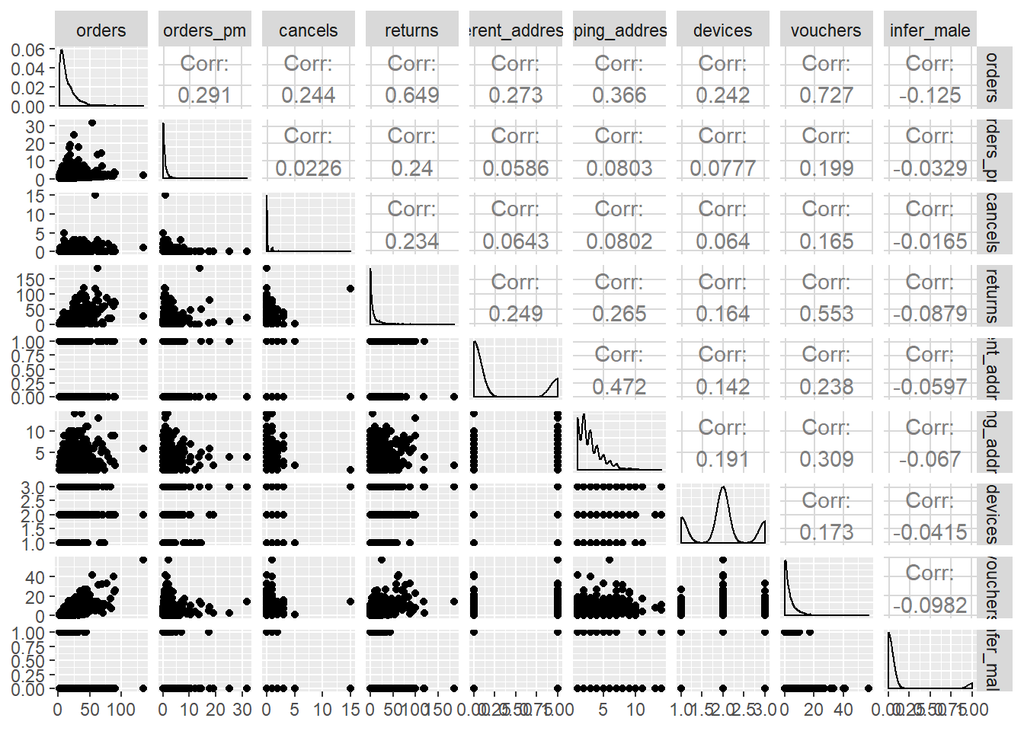

#### Delivery Point Related

- No correlations to be reported.

```r
X2<-df7_c[,c("work_orders","home_orders","parcelpoint_orders",
             "other_collection_orders","infer_male")]
```

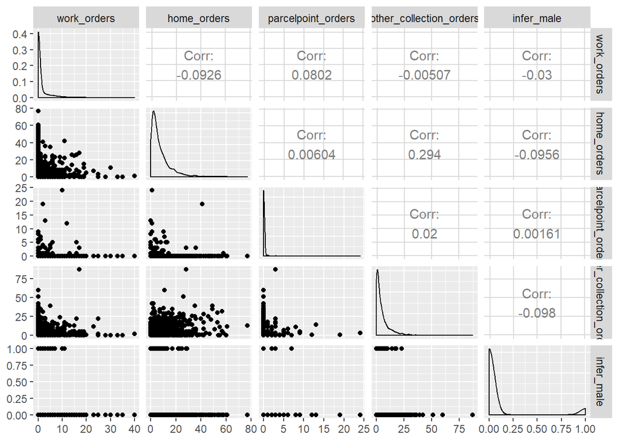

#### Payment Related

- Redpen discount used and coupon discount applied
- Redpen discount used and revenue
- Coupon discount applied and revenue

```r
X3 <-df7_c[,c("cc_payments","paypal_payments","afterpay_payments",
           "apple_payments","redpen_discount_used",
           "coupon_discount_applied","average_discount_onoffer",
           "average_discount_used","revenue","infer_male")]
```

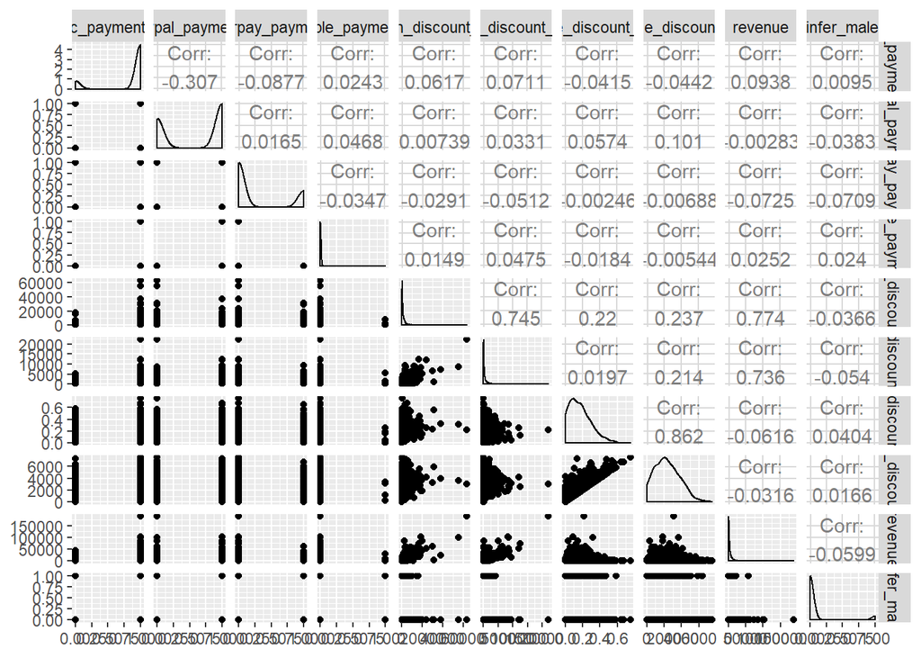

#### Cart Related - Male (for analysis)

- Sports accessories and unisex items (expected)

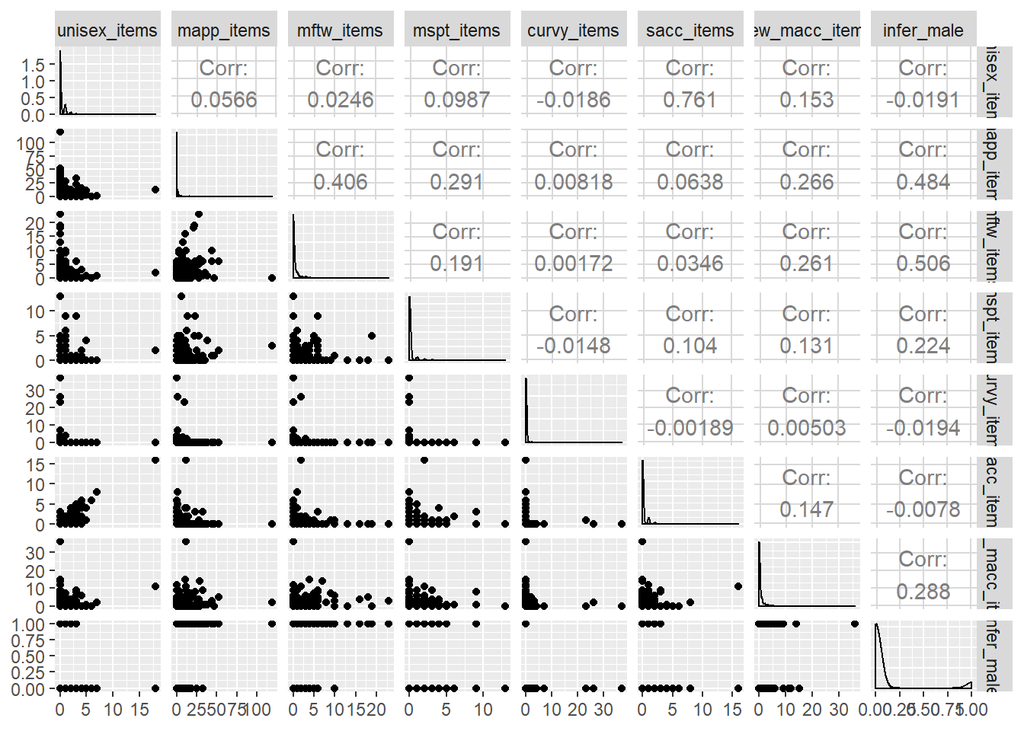

```r
X4 <- df7_c[,c("unisex_items","mapp_items","mftw_items","mspt_items",
               "curvy_items","sacc_items","new_macc_items","infer_male")]
```

#### Cart Related - Female (for analysis)

```r
X4_1 <- df7_c[,c("unisex_items","wapp_items","wftw_items","wspt_items","curvy_items","sacc_items","new_wacc_items","infer_male")]
```

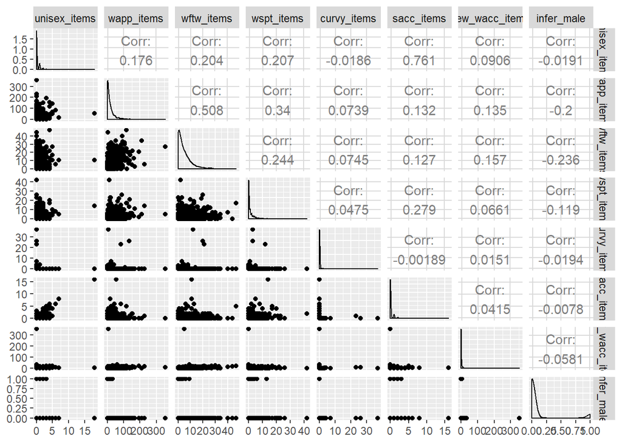

##### Deep-dive on female correlations

All correlations under control. A different view for easier comparison.

```r
M <- cor(X4_1)
M1 <- cor(X3)
```

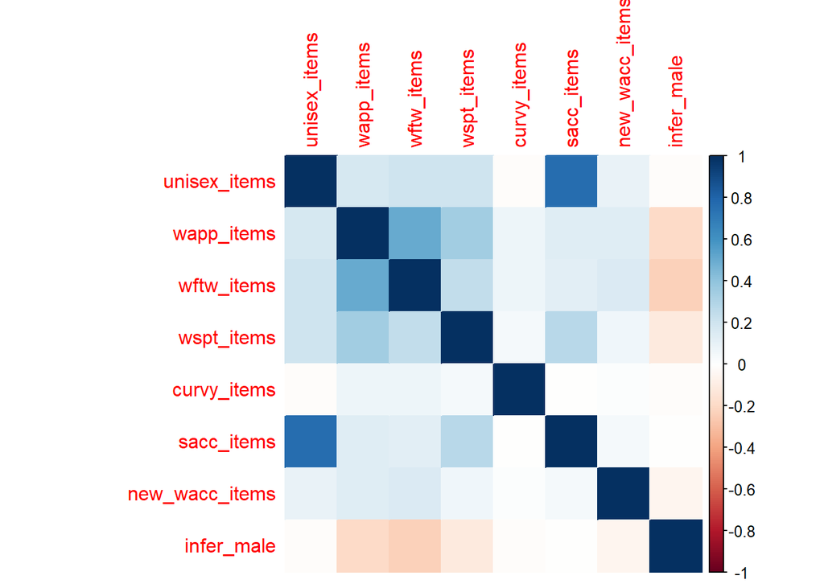

##### Deep-dive on payment related and discount coupon usage

Doing the same grid for the most correlated sets together - payment and coupon discount themed variables. Notable correlation: -Average discount used and avg discount on offer (expected)

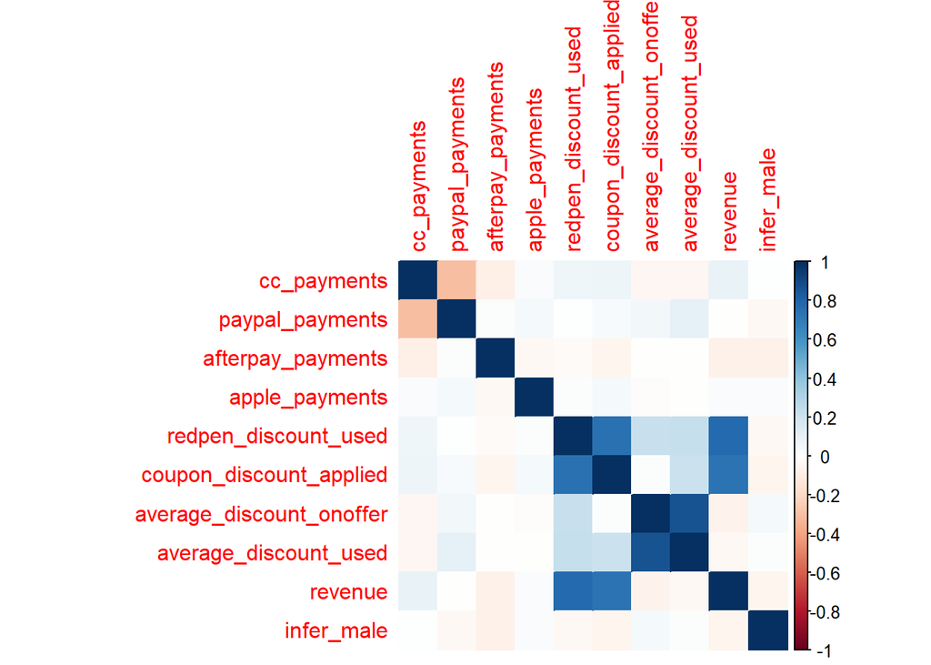

#### Browsing Behavior Related

- No correlations to be reported

```r
X5 <- df7_c[,c("msite_orders","desktop_orders","android_orders",
               "ios_orders","other_device_orders","infer_male")]
```

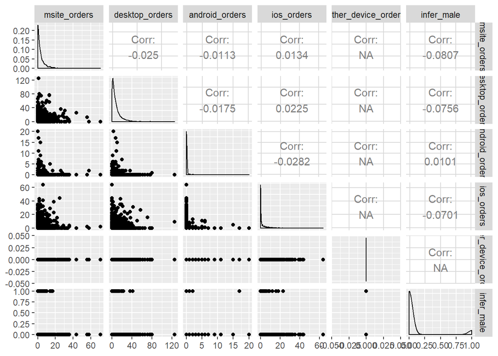

```r
rm(X,X1,X2,X3,X4,X4_1,X5,df_check,df7_c)
rm(M,M1)
```

## 2(c) Analysing the candidates for removal

```r
summary(df7[,c("wapp_items","wftw_items","sacc_items","unisex_items",
               "coupon_discount_applied","redpen_discount_used","revenue",
               "average_discount_onoffer","average_discount_used","returns","orders","vouchers")])
```

```
##    wapp_items       wftw_items       sacc_items       unisex_items
##  Min.   :  0.00   Min.   : 0.000   Min.   : 0.0000   Min.   : 0.0000
##  1st Qu.:  3.00   1st Qu.: 1.000   1st Qu.: 0.0000   1st Qu.: 0.0000
##  Median : 11.00   Median : 3.000   Median : 0.0000   Median : 0.0000
##  Mean   : 19.13   Mean   : 5.242   Mean   : 0.1986   Mean   : 0.2709
##  3rd Qu.: 24.00   3rd Qu.: 7.000   3rd Qu.: 0.0000   3rd Qu.: 0.0000
##  Max.   :356.00   Max.   :47.000   Max.   :16.0000   Max.   :18.0000
##  coupon_discount_applied redpen_discount_used    revenue
##  Min.   :    0.0         Min.   :    0.0      Min.   :    21.78
##  1st Qu.:   10.9         1st Qu.:  162.6      1st Qu.:   965.01
##  Median :  128.9         Median :  547.2      Median :  2311.24
##  Mean   :  542.2         Mean   : 1550.8      Mean   :  5282.21
##  3rd Qu.:  516.5         3rd Qu.: 1637.6      3rd Qu.:  5515.97
##  Max.   :22213.1         Max.   :63265.5      Max.   :187783.14
##  average_discount_onoffer average_discount_used    returns
##  Min.   :0.0000           Min.   :   0          Min.   :  0.000
##  1st Qu.:0.0749           1st Qu.:1250          1st Qu.:  0.000
##  Median :0.1569           Median :2241          Median :  2.000
##  Mean   :0.1733           Mean   :2365          Mean   :  7.548
##  3rd Qu.:0.2499           3rd Qu.:3323          3rd Qu.:  8.000
##  Max.   :0.7500           Max.   :7500          Max.   :185.000
##      orders          vouchers
##  Min.   :  2.00   Min.   : 0.000
##  1st Qu.:  6.00   1st Qu.: 1.000
##  Median : 10.00   Median : 2.000
##  Mean   : 14.26   Mean   : 3.446
##  3rd Qu.: 19.00   3rd Qu.: 5.000
##  Max.   :135.00   Max.   :57.000
```

I recommend checking coeff of variation as well - similar to ANOVA

```r
library(raster)
cv(df7[,"wftw_items"],aszero=TRUE, na.rm = TRUE)
```

```
## [1] 116.8738
```

```r
cv(df7[,"wapp_items"],aszero=TRUE, na.rm = TRUE)
```

```
## [1] 138.7001
```

```r
cv(df7[,"sacc_items"],aszero=TRUE, na.rm = TRUE)
```

```
## [1] 369.4766
```

```r
cv(df7[,"unisex_items"],aszero=TRUE, na.rm = TRUE)
```

```
## [1] 305.429
```

```r
cv(df7[,"coupon_discount_applied"],aszero=TRUE, na.rm = TRUE)
```

```
## [1] 231.6424
```

```r
cv(df7[,"redpen_discount_used"],aszero=TRUE, na.rm = TRUE)
```

```
## [1] 225.2332
```

```r
cv(df7[,"revenue"],aszero=TRUE, na.rm = TRUE)
```

```
## [1] 192.4442
```

```r
cv(df7[,"average_discount_onoffer"],aszero=TRUE, na.rm = TRUE)
```

```
## [1] 72.84344
```

```r
cv(df7[,"average_discount_used"],aszero=TRUE, na.rm = TRUE)
```

```
## [1] 60.47599
```

```r
cv(df7[,"returns"],aszero=TRUE, na.rm = TRUE)
```

```
## [1] 188.4945
```

```r
cv(df7[,"orders"],aszero=TRUE, na.rm = TRUE)
```

```
## [1] 91.86037
```

```r
cv(df7[,"vouchers"],aszero=TRUE, na.rm = TRUE)
```

```
## [1] 135.1733
```

```r
detach("package:raster", unload=TRUE)
```

Removing the variables:  
– Red pen discount is not as useful,coupon discount applied a better candidate (more tangible impact)  
– unisex & sports accessory items by definition are not used in female/male items directly (also low cardinality, need bigger sample)  
– Women Footwear and Women Apparel are highly correlated. Keep one with higher variablity. Hence, apparel chosen.  
– average discount on offer is not guaranteeing a customer opt-in (‘applied’ is a better candidate)  
– other_device_orders doesnt have any variablity  
– revenue is a post facto measurement of preferences, plus it frequently changes meaning model needs to re-score (potentially every few weeks)  
– other_collection_orders is not useful in measuring preferences (other is a remainder of other categories)  
– days since first order is too far out, a recent measure is preferred. Months active is a better fit.

```r
md_base <- subset(df7,select= -c(wftw_items,customer_id,unisex_items,
                                 average_discount_onoffer,redpen_discount_used,
                        revenue,other_device_orders,orders,other_collection_orders,
                                 days_since_first_order))
```

# *Part 3 Modelling Dataset*

> Traditional 70-30 split done for modelling use. Ideally, if the sample size was more - i would like to have created a separate evaluation for cross validation in the scheme (70-15-15). Cross validation for now, is done within the modelling dataset by repeated sampling with replacement.

```r
library(caTools)
set.seed(217945)
split = sample.split(md_base$infer_male, SplitRatio = 0.70)
mod_df = subset(md_base, split == TRUE) #Modelling Data
valid_df = subset(md_base, split == FALSE)  #Holdout validation sample
```

Checking the population splits: male vs female labels Response rates hover around 8-9%.

```r
table(mod_df$infer_male)
```

```
##
##   0   1
## 975  90
```

```r
table(valid_df$infer_male)
```

```
##
##   0   1
## 418  38
```

```r
detach("package:caTools", unload=TRUE)
```

# *Part 4: Variable Selection*

> I split the variable selection into two parts - Collinearity checks further based on linear regression output and then using logistic regression to keep only the significant variables for ML methods. ML methods are extremely sensitive to number of predictors thrown in and there needs to be thoughtful caution in selecting the right predictors that combine business sense with statistical drive.

## 4(a): Linear Regression and VIF measures (collinearity)

Categorical label is converted to numeric for this piece.

```r
library(car)
mod_df_lm <- mod_df
mod_df_lm$infer_male <- as.numeric(mod_df_lm$infer_male)
lin.reg <- lm(formula = infer_male ~ ., data = mod_df_lm)
summary(lin.reg)
```

```
##
## Call:
## lm(formula = infer_male ~ ., data = mod_df_lm)
##
## Residuals:
##      Min       1Q   Median       3Q      Max
## -0.93357 -0.09154 -0.03665  0.01948  0.94417
##
## Coefficients:
##                            Estimate Std. Error t value Pr(>|t|)
## (Intercept)               1.164e+00  3.439e-02  33.844  < 2e-16 ***
## days_since_last_order    -1.632e-05  1.733e-05  -0.942 0.346586
## is_newsletter_subscriber -7.364e-02  1.634e-02  -4.508 7.30e-06 ***
## cancels                   5.648e-03  1.132e-02   0.499 0.617876
## returns                  -5.272e-04  7.918e-04  -0.666 0.505688
## different_addresses      -8.353e-03  1.736e-02  -0.481 0.630578
## shipping_addresses       -8.600e-03  4.269e-03  -2.014 0.044225 *
## devices                  -5.629e-03  1.043e-02  -0.540 0.589645
## vouchers                 -4.774e-04  2.365e-03  -0.202 0.840050
## cc_payments               5.274e-02  2.004e-02   2.631 0.008632 **
## paypal_payments           1.737e-03  1.475e-02   0.118 0.906258
## afterpay_payments        -1.502e-02  1.497e-02  -1.003 0.316028
## apple_payments           -9.813e-02  1.229e-01  -0.798 0.424957
## wapp_items               -3.540e-04  6.231e-04  -0.568 0.570118
## mapp_items                1.589e-02  1.307e-03  12.157  < 2e-16 ***
## mftw_items                5.609e-02  4.504e-03  12.454  < 2e-16 ***
## wspt_items                4.704e-04  2.337e-03   0.201 0.840505
## mspt_items                2.994e-02  8.707e-03   3.438 0.000609 ***
## curvy_items              -3.330e-04  4.117e-03  -0.081 0.935556
## sacc_items               -1.758e-02  8.795e-03  -1.998 0.045934 *
## msite_orders             -2.181e-03  1.895e-03  -1.151 0.250021
## desktop_orders           -1.822e-03  1.676e-03  -1.087 0.277271
## android_orders            2.695e-03  5.973e-03   0.451 0.651923
## ios_orders               -3.651e-03  2.049e-03  -1.782 0.075076 .
## work_orders              -1.793e-03  2.059e-03  -0.871 0.384193
## home_orders              -1.652e-03  1.590e-03  -1.039 0.299035
## parcelpoint_orders        8.147e-03  8.378e-03   0.972 0.331057
## coupon_discount_applied   8.190e-06  9.591e-06   0.854 0.393343
## average_discount_used    -1.129e-05  4.955e-06  -2.279 0.022862 *
## new_macc_items            2.935e-02  4.262e-03   6.887 9.86e-12 ***
## new_wacc_items           -2.056e-03  2.457e-03  -0.837 0.402954
## mths_active               6.842e-05  5.358e-04   0.128 0.898403
## orders_pm                 1.683e-03  4.511e-03   0.373 0.709115
## ---
## Signif. codes:  0 '***' 0.001 '**' 0.01 '*' 0.05 '.' 0.1 ' ' 1
##
## Residual standard error: 0.2081 on 1032 degrees of freedom
## Multiple R-squared:  0.4576, Adjusted R-squared:  0.4408
## F-statistic: 27.21 on 32 and 1032 DF,  p-value: < 2.2e-16
```

```r
vif(lin.reg)
```

```
##    days_since_last_order is_newsletter_subscriber                  cancels
##                 1.724312                 1.118299                 1.181582
##                  returns      different_addresses       shipping_addresses
##                 3.049590                 1.399674                 1.631744
##                  devices                 vouchers              cc_payments
##                 1.231159                 3.428728                 1.228567
##          paypal_payments        afterpay_payments           apple_payments
##                 1.294026                 1.082933                 1.044144
##               wapp_items               mapp_items               mftw_items
##                 6.788842                 1.438701                 1.292275
##               wspt_items               mspt_items              curvy_items
##                 1.399511                 1.170761                 1.051955
##               sacc_items             msite_orders           desktop_orders
##                 1.198434                 3.196841                 7.794156
##           android_orders               ios_orders              work_orders
##                 1.157487                 3.537333                 1.680132
##              home_orders       parcelpoint_orders  coupon_discount_applied
##                 4.951974                 1.108378                 3.013474
##    average_discount_used           new_macc_items           new_wacc_items
##                 1.199643                 1.183059                 1.593161
##              mths_active                orders_pm
##                 2.144354                 1.500314
```

```r
rm(mod_df_lm)
```

in addition, some of the variables like paypal_payments and cancels are way too insignificant.

Removing the variables from the modelling and holdout as a result of VIF analysis (1 out of the pair of 2): After this, another round of VIFs are run:

```r
mod_df <- select(mod_df,-c(vouchers,wapp_items,desktop_orders,home_orders,paypal_payments,cancels))
mod_df_lm <- mod_df
mod_df_lm$infer_male <- as.numeric(mod_df_lm$infer_male)
lin.reg1 <- lm(formula = infer_male ~ ., data = mod_df_lm)
summary(lin.reg1)
```

```
##
## Call:
## lm(formula = infer_male ~ ., data = mod_df_lm)
##
## Residuals:
##      Min       1Q   Median       3Q      Max
## -0.92161 -0.08934 -0.03450  0.01629  0.96842
##
## Coefficients:
##                            Estimate Std. Error t value Pr(>|t|)
## (Intercept)               1.166e+00  3.243e-02  35.954  < 2e-16 ***
## days_since_last_order    -1.256e-05  1.631e-05  -0.770  0.44120
## is_newsletter_subscriber -8.038e-02  1.619e-02  -4.966 7.99e-07 ***
## returns                  -1.775e-03  6.400e-04  -2.774  0.00564 **
## different_addresses      -9.660e-03  1.736e-02  -0.556  0.57810
## shipping_addresses       -9.976e-03  4.212e-03  -2.368  0.01805 *
## devices                  -3.395e-03  1.042e-02  -0.326  0.74457
## cc_payments               4.741e-02  1.876e-02   2.527  0.01166 *
## afterpay_payments        -1.733e-02  1.500e-02  -1.155  0.24838
## apple_payments           -6.820e-02  1.226e-01  -0.556  0.57830
## mapp_items                1.589e-02  1.270e-03  12.518  < 2e-16 ***
## mftw_items                5.512e-02  4.448e-03  12.392  < 2e-16 ***
## wspt_items               -1.359e-03  2.252e-03  -0.604  0.54630
## mspt_items                2.839e-02  8.674e-03   3.273  0.00110 **
## curvy_items              -2.167e-03  4.078e-03  -0.531  0.59531
## sacc_items               -2.072e-02  8.736e-03  -2.371  0.01790 *
## msite_orders             -2.400e-03  1.184e-03  -2.027  0.04293 *
## android_orders            4.251e-03  5.726e-03   0.742  0.45804
## ios_orders               -3.570e-03  1.258e-03  -2.839  0.00461 **
## work_orders              -1.655e-03  1.678e-03  -0.987  0.32399
## parcelpoint_orders        9.726e-03  8.229e-03   1.182  0.23751
## coupon_discount_applied   6.525e-06  7.595e-06   0.859  0.39044
## average_discount_used    -1.161e-05  4.824e-06  -2.407  0.01626 *
## new_macc_items            2.864e-02  4.247e-03   6.744 2.55e-11 ***
## new_wacc_items           -4.305e-03  2.310e-03  -1.863  0.06273 .
## mths_active              -1.220e-04  4.988e-04  -0.244  0.80689
## orders_pm                -1.721e-03  4.422e-03  -0.389  0.69722
## ---
## Signif. codes:  0 '***' 0.001 '**' 0.01 '*' 0.05 '.' 0.1 ' ' 1
##
## Residual standard error: 0.2088 on 1038 degrees of freedom
## Multiple R-squared:  0.4507, Adjusted R-squared:  0.4369
## F-statistic: 32.76 on 26 and 1038 DF,  p-value: < 2.2e-16
```

```r
vif(lin.reg1)
```

```
##    days_since_last_order is_newsletter_subscriber                  returns
##                 1.516304                 1.090418                 1.978423
##      different_addresses       shipping_addresses                  devices
##                 1.390241                 1.577526                 1.218862
##              cc_payments        afterpay_payments           apple_payments
##                 1.069128                 1.079732                 1.031996
##               mapp_items               mftw_items               wspt_items
##                 1.348471                 1.251700                 1.290987
##               mspt_items              curvy_items               sacc_items
##                 1.153844                 1.025051                 1.174387
##             msite_orders           android_orders               ios_orders
##                 1.239891                 1.056350                 1.323319
##              work_orders       parcelpoint_orders  coupon_discount_applied
##                 1.107654                 1.062072                 1.876767
##    average_discount_used           new_macc_items           new_wacc_items
##                 1.129512                 1.166849                 1.399431
##              mths_active                orders_pm
##                 1.846131                 1.431796
```

Now, all VIFs are in control. Correlations are checked again below to be sure. Nothing to be reported there.

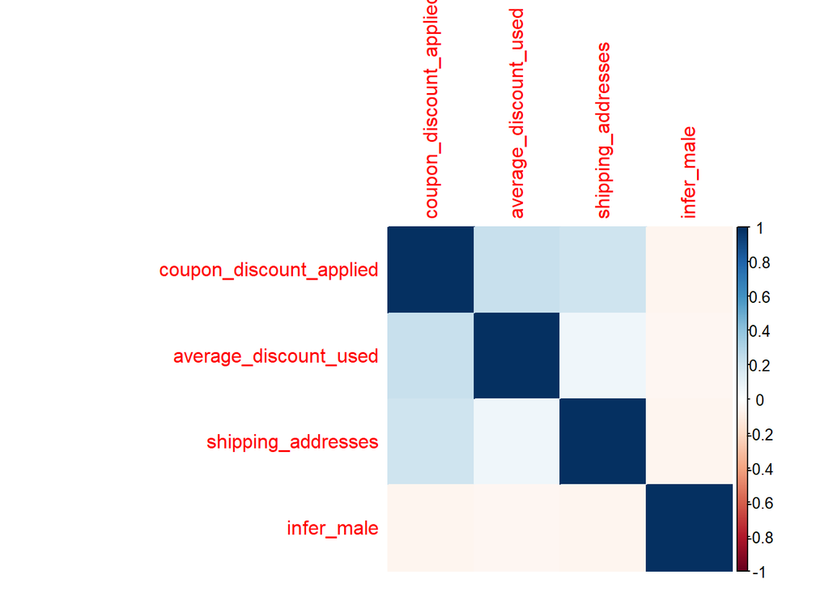

```r
M1 <- cor(subset(mod_df_lm,select= c(coupon_discount_applied,average_discount_used,
                                    shipping_addresses,infer_male)))
corrplot(M1, method="color")
```

```r
rm(mod_df_lm,M1)
```

```r
detach("package:car", unload=TRUE)
```

we can remove highly insignificant variables: – Different addresses – Apple payments – Wspt items – Curvy items

```r
mod_df <- select(mod_df,-c(different_addresses,apple_payments,wspt_items,curvy_items))
```

## 4(b): Logistic for Var Selection continued…

Now, we use a quick diagnostic model to remove variables which might have a directional effect (captured in linear regression) but, do not help in creating decision boundaries. Hence, stepwise forward model would be suited to capture best predictors for advancing to ML methods.

```r
library(MASS)
null <- glm(infer_male ~ 0, family = binomial(link = "logit"), mod_df) #Null Model
full <- glm(infer_male ~ ., family = binomial(link = "logit"), mod_df) #Full Model
aic_steps <- step(null, scope=list(lower=null, upper=full), direction="forward", k=2,trace=FALSE)
summary(aic_steps)  #Stepwise summary
```

```
##
## Call:
## glm(formula = infer_male ~ devices + mapp_items + returns + mftw_items +
##     ios_orders + average_discount_used + msite_orders + mspt_items +
##     coupon_discount_applied + new_macc_items + shipping_addresses +
##     orders_pm + is_newsletter_subscriber + new_wacc_items - 1,
##     family = binomial(link = "logit"), data = mod_df)
##
## Deviance Residuals:
##     Min       1Q   Median       3Q      Max
## -2.2789  -0.0676  -0.0032   0.0000   3.3125
##
## Coefficients:
##                            Estimate Std. Error z value Pr(>|z|)
## devices                  -0.1910824  0.3687758  -0.518 0.604351
## mapp_items                0.9936342  0.1557944   6.378 1.80e-10 ***
## returns                  -0.8307718  0.2309538  -3.597 0.000322 ***
## mftw_items                1.9411338  0.3694562   5.254 1.49e-07 ***
## ios_orders               -0.7570643  0.2923407  -2.590 0.009607 **
## average_discount_used    -0.0003402  0.0001736  -1.959 0.050088 .
## msite_orders             -0.7186929  0.1631119  -4.406 1.05e-05 ***
## mspt_items                1.8055031  0.3948970   4.572 4.83e-06 ***
## coupon_discount_applied  -0.0038591  0.0013360  -2.889 0.003871 **
## new_macc_items            0.9090340  0.2437438   3.729 0.000192 ***
## shipping_addresses       -0.4212649  0.2565725  -1.642 0.100612
## orders_pm                -1.0949121  0.6094572  -1.797 0.072409 .
## is_newsletter_subscriber -0.8170947  0.5299878  -1.542 0.123141
## new_wacc_items           -0.4253973  0.3144031  -1.353 0.176046
## ---
## Signif. codes:  0 '***' 0.001 '**' 0.01 '*' 0.05 '.' 0.1 ' ' 1
##
## (Dispersion parameter for binomial family taken to be 1)
##
##     Null deviance: 1476.4  on 1065  degrees of freedom
## Residual deviance:  114.2  on 1051  degrees of freedom
## AIC: 142.2
##
## Number of Fisher Scoring iterations: 11
```

```r
detach("package:MASS", unload=TRUE)
```

> Keeping the most important variables for machine learning methods is the key here. This table can be interpreted in so many different ways. Men vs women trends come out well and we can attribute shopping behaviors to each class.

> Men generally have lower number of devices (insignificant by itself) but, this is coupled by low number of msite orders and even lower iOS orders. Hence, they can be thought of as tied to desktop devices - they like look and feel of the product. Men are also less price conscious (low average discount used) and low item level coupon discounts. They return items lesser and buy male items in higher numbers. Most significant item after apprarel is footwear. This is expected since footwear is sensitive to fit, sizes, shapes and other considerations. People buy for themselves usually and hence, it can be a good feature to predict gender.

Hence, only the select features will be deployed for ML use.

```r
mod_df_copy <- select(mod_df,c(devices,mftw_items,mapp_items,returns,new_wacc_items,
                                   new_macc_items,shipping_addresses,orders_pm,mspt_items,
                                   msite_orders,ios_orders,coupon_discount_applied,
                                   is_newsletter_subscriber,average_discount_used,infer_male))
```

# *Part 5: Advanced Machine Learning Model Build*

## 5(a): Foundations: Single Decision Tree

```r
dt <- rpart(infer_male~.,data=mod_df_copy,method="class",control=rpart.control(minsplit=5,minbucket=5,maxdepth=9))
#summary(dt)
printcp(dt) # display the results
```

```
##
## Classification tree:
## rpart(formula = infer_male ~ ., data = mod_df_copy, method = "class",
##     control = rpart.control(minsplit = 5, minbucket = 5, maxdepth = 9))
##
## Variables actually used in tree construction:
## [1] coupon_discount_applied ios_orders              mapp_items
## [4] mftw_items              new_wacc_items          orders_pm
## [7] returns
##
## Root node error: 90/1065 = 0.084507
##
## n= 1065
##
##         CP nsplit rel error  xerror     xstd
## 1 0.166667      0   1.00000 1.00000 0.100857
## 2 0.155556      1   0.83333 0.98889 0.100347
## 3 0.055556      2   0.67778 0.84444 0.093344
## 4 0.037037      4   0.56667 0.76667 0.089256
## 5 0.033333      7   0.45556 0.72222 0.086804
## 6 0.022222      8   0.42222 0.71111 0.086177
## 7 0.016667      9   0.40000 0.66667 0.083607
## 8 0.010000     11   0.36667 0.64444 0.082283
```

## 5(b): Improvisation: Random Forest (with H2o Java API Tuning)

#### H2o for RF Tuning

> HyperParameter Tuning

The following code invokes H2o API - currently commented out for Rmarkdown rendering. 64 bit Java installation on desktop is the key requirement for opening up server hub for on the fly computation. This will help tune the RF algorithm without bias and help reduce error variance.

It is currently commented out for markdown rendering, but can be opened up.

```r
#library(h2o)
#set.seed(217945)
#h2o.init(max_mem_size = "5g")

#train.h2o <- as.h2o(mod_df_copy)    #H2o object for training


#hyper_grid.h2o <- list(
#  ntrees      = seq(50, 300, by = 20),
#  mtries      = seq(2, 8, by = 1),
# max_depth   = seq(2, 8, by = 1)
#)

#search_criteria <- list(
#  strategy = "RandomDiscrete",
#  stopping_metric = "misclassification",
#  stopping_tolerance = 0.005,
#  stopping_rounds = 5,
#  max_runtime_secs = 30*60
#)

#random_grid <- h2o.grid(
#  algorithm = "randomForest",
#  grid_id = "rf_grid2",
#  x = features,
#  y = "infer_male",
#  training_frame = train.h2o,
#  hyper_params = hyper_grid.h2o,
#  search_criteria = search_criteria
#)

#grid_perf2 <- h2o.getGrid(
#  grid_id = "rf_grid2",
#  sort_by = "mse",
#  decreasing = TRUE
#)
#print(grid_perf2)   #Printing the optimised list

#h2o.shutdown(prompt=FALSE)
```

#### Optimised RF Tree Run for prediction

Bootstrap aggregating random forest trees will combine a large collection of de-correlated trees to vote the final outcome as a majority of all the tree outcomes. This will be a key technique to test here. With parameter tuning, Split-variable randomization also occurs. Only 4 of the variables are tried at once out of the overall set(14) with max-depth = 8. The trees are designed to be deep.

out-of-bag (OOB) sample that provides an efficient and reasonable approximation of the test error.

```r
m1 <- randomForest(infer_male~.,data=mod_df_copy,ntree=250,mtry=4,max_depth=8)
m1
```

```
##
## Call:
##  randomForest(formula = infer_male ~ ., data = mod_df_copy, ntree = 250,      mtry = 4, max_depth = 8)
##                Type of random forest: classification
##                      Number of trees: 250
## No. of variables tried at each split: 4
##
##         OOB estimate of  error rate: 4.32%
## Confusion matrix:
##     0  1 class.error
## 0 968  7 0.007179487
## 1  39 51 0.433333333
```

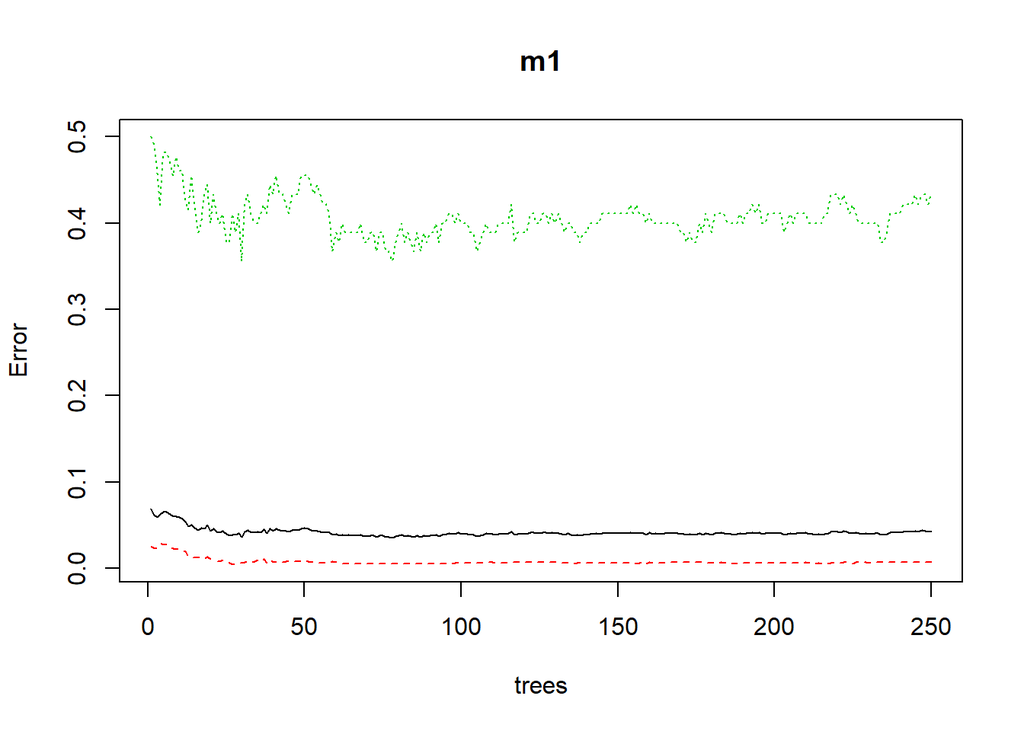

```r
plot(m1)
```

```r
m1$importance
```

```
##                          MeanDecreaseGini
## devices                          2.871691
## mftw_items                      30.033386
## mapp_items                      40.478476
## returns                          8.497726
## new_wacc_items                  10.367147
## new_macc_items                  13.095024
## shipping_addresses               3.356080
## orders_pm                       15.135365
## mspt_items                       7.982646
## msite_orders                     5.183499
## ios_orders                       5.261293
## coupon_discount_applied          9.915535
## is_newsletter_subscriber         2.831270
## average_discount_used            8.409365
```

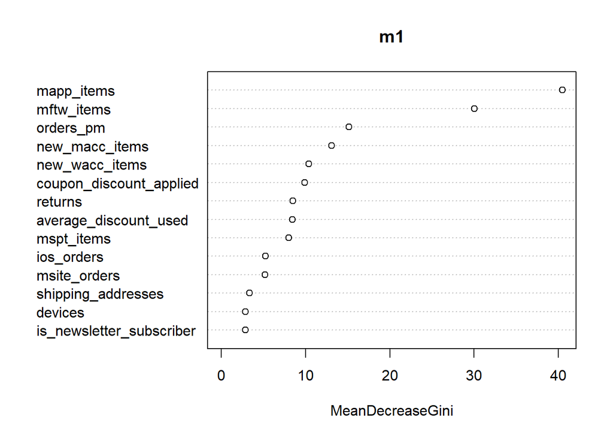

```r
varImpPlot(m1,type=2)
```

The most important variables are as expected from the earlier logistic regression. ML methods are able to tune accuracy very high as they’re able to learn themselves.

Populating the predictions from the optimised tree on the holdout sample.

```r
pred_rf <-predict(m1,valid_df)
pred_rf1<-cbind(pred_rf,valid_df)

confusionMatrix(pred_rf1$pred_rf,
                pred_rf1$infer_male,
                mode = "everything")
```

```
## Confusion Matrix and Statistics
##
##           Reference
## Prediction   0   1
##          0 412   9
##          1   6  29
##
##                Accuracy : 0.9671
##                  95% CI : (0.9463, 0.9815)
##     No Information Rate : 0.9167
##     P-Value [Acc > NIR] : 1.019e-05
##
##                   Kappa : 0.7767
##  Mcnemar's Test P-Value : 0.6056
##
##             Sensitivity : 0.9856
##             Specificity : 0.7632
##          Pos Pred Value : 0.9786
##          Neg Pred Value : 0.8286
##               Precision : 0.9786
##                  Recall : 0.9856
##                      F1 : 0.9821
##              Prevalence : 0.9167
##          Detection Rate : 0.9035
##    Detection Prevalence : 0.9232
##       Balanced Accuracy : 0.8744
##
##        'Positive' Class : 0
##
```

```r
rm(pred_rf)
```

The confusion matrix shows ~97% accuracy. I typically look for F1 score as it is harmonic mean of Precision and Recall.

## 5(c): Further Refinement: Random Forest (with SMOTE oversampling)

Sythetic Minority Oversampling technique (SMOTE) is another method we try and boost predictions with. To compare, we keep the number of features and trees constant, and then boost this with creating synthetic data points across the known labels to boost accuracy.

```r
library("DMwR")
```

```r
ctrl <- trainControl(method = "repeatedcv",
                     number = 10,
                     repeats = 10,
                     verboseIter = FALSE,
                     search="grid",
                     p=0.10,
                     sampling = "smote")

tunegrid <- expand.grid(.mtry=c(2:9))
m2 <- caret::train(infer_male ~ .,
                              data = mod_df_copy,
                              method = "rf",
                              metric = "Accuracy",
                              tuneGrid=tunegrid,
                              trControl = ctrl,
                              ntree=250 # Held constant for comparing Random forest in 5(b)
                              )
rm(ctrl,tunegrid)
```

```r
m2
```

```
## Random Forest
##
## 1065 samples
##   14 predictor
##    2 classes: '0', '1'
##
## No pre-processing
## Resampling: Cross-Validated (10 fold, repeated 10 times)
## Summary of sample sizes: 959, 958, 959, 958, 959, 959, ...
## Addtional sampling using SMOTE
##
## Resampling results across tuning parameters:
##
##   mtry  Accuracy   Kappa
##   2     0.9613234  0.7578719
##   3     0.9584042  0.7504391
##   4     0.9551076  0.7359204
##   5     0.9519326  0.7212107
##   6     0.9508993  0.7195292
##   7     0.9487383  0.7062509
##   8     0.9462802  0.6984287
##   9     0.9465756  0.6980789
##
## Accuracy was used to select the optimal model using the largest value.
## The final value used for the model was mtry = 2.
```

```r
m2$results
```

```
##   mtry  Accuracy     Kappa AccuracySD    KappaSD
## 1    2 0.9613234 0.7578719 0.01623401 0.09849869
## 2    3 0.9584042 0.7504391 0.01888990 0.10768646
## 3    4 0.9551076 0.7359204 0.01877424 0.10189770
## 4    5 0.9519326 0.7212107 0.02125841 0.11206818
## 5    6 0.9508993 0.7195292 0.02039936 0.09685229
## 6    7 0.9487383 0.7062509 0.01915119 0.10064486
## 7    8 0.9462802 0.6984287 0.02333614 0.10948114
## 8    9 0.9465756 0.6980789 0.02261713 0.11231045
```

Generating predictions on holdout for SMOTE derived modelling estimates

```r
pred_rf_os <-predict(m2,valid_df)
pred_rf_os <-cbind(pred_rf_os,valid_df)
confusionMatrix(pred_rf_os$pred_rf_os,
                pred_rf_os$infer_male,
                mode = "everything")
```

```
## Confusion Matrix and Statistics
##
##           Reference
## Prediction   0   1
##          0 398   5
##          1  20  33
##
##                Accuracy : 0.9452
##                  95% CI : (0.9201, 0.9642)
##     No Information Rate : 0.9167
##     P-Value [Acc > NIR] : 0.01333
##
##                   Kappa : 0.6957
##  Mcnemar's Test P-Value : 0.00511
##
##             Sensitivity : 0.9522
##             Specificity : 0.8684
##          Pos Pred Value : 0.9876
##          Neg Pred Value : 0.6226
##               Precision : 0.9876
##                  Recall : 0.9522
##                      F1 : 0.9695
##              Prevalence : 0.9167
##          Detection Rate : 0.8728
##    Detection Prevalence : 0.8838
##       Balanced Accuracy : 0.9103
##
##        'Positive' Class : 0
##
```

> This is is an important comparison since we get slightly more male customers predicted, but increases false positives. F1 score hence goes slightly lower. We shall come back to it at a later point. Time for some boosting!

## 5(d): Gradient Boosting: eXtreme Gradient Boosting Machines (xGBoost)

> Technically this is a more superior technique than RF since it goes sequentially to eliminate errors. It has capacity to do parallel computation on a single machine. XGBoost only works with numeric vectors.

Hence, we convert the feature space into a sparse matrix. Also, we store the labels separately.

```r
library(Matrix)
sparse_matrix <- sparse.model.matrix(infer_male ~ ., data = mod_df_copy)[,-1]
y <- as.numeric(mod_df_copy$infer_male)-1
```

Preparing the training scheme: We shall tune the model for best results in a hyper-parameter search and then train the model.

```r
#ctrl <- trainControl(method="cv", number=10, allowParallel = TRUE)
```

Next, design the parameter tuning grid - gridsearch takes a host of different parameters: the key being leaf node size, max depth, learning rate and sub sample of features (randomize the noise). >It has been commented out for rmarkdown rendering, but it can be placed back in.

```r
#xgbGrid <- expand.grid(nrounds = seq(1,10,by=1),
#                       max_depth = seq(2,6,by=1),
#                       eta = c(0.1,0.2,0.3),
#                       rate_drop = 0,
#                       skip_drop = 0,
#                       colsample_bytree = seq(0.3,1,by=0.1),
#                       min_child_weight = 10,
#                       subsample = seq(0.3,1,by=0.1),
#                       gamma = 0.01
#                      )
```

Invoking the gridsearch for finding the right hyper-parameters,

```r
#xm_train <- train(sparse_matrix,
#                  mod_df_copy$infer_male,
#                  method="xgbDART",
#                  eval_metric="error",
#                  trControl=ctrl,
#                  tuneGrid = xgbGrid)
```

```r
#xm_train$modelType
#xm_train$method
#head(xm_train$results)
#xm_train$finalModel
#print(xm_train$bestTune)
```

Using these results to get the estimates on the modelling dataset:

```r
x1 <- xgboost(
              data = sparse_matrix,
              label = y,
              max_depth = 6,
              nfeatures=9,
              learn_rate = 0.3,
              sample_rate = 1,
              nfold=10,  #dont require a separate cross validation call
              nrounds = 9,objective = "multi:softprob",
              "eval_metric" = "merror",
              "num_class" = 2)
```

Checking variable importances on the fitted model:

```r
importance <- xgb.importance(feature_names = colnames(sparse_matrix), model = x1)
importance
```

```
##                      Feature        Gain       Cover  Frequency
##  1:               mapp_items 0.247504963 0.269181072 0.15966387
##  2:               mftw_items 0.232126376 0.177765818 0.07142857
##  3:           new_wacc_items 0.136963416 0.031216997 0.08403361
##  4:                orders_pm 0.090072291 0.124600745 0.10504202
##  5:  coupon_discount_applied 0.062333774 0.022508199 0.08403361
##  6:                  returns 0.060468784 0.016515737 0.07983193
##  7:           new_macc_items 0.038781959 0.118579348 0.07983193
##  8:    average_discount_used 0.036708624 0.054158773 0.09663866
##  9:             msite_orders 0.030294282 0.011744853 0.06302521
## 10:               ios_orders 0.026820885 0.008789776 0.05042017
## 11:               mspt_items 0.018406526 0.154332690 0.05462185
## 12:       shipping_addresses 0.011048005 0.005255282 0.04201681
## 13: is_newsletter_subscriber 0.005396778 0.004069790 0.01680672
## 14:                  devices 0.003073337 0.001280920 0.01260504
```

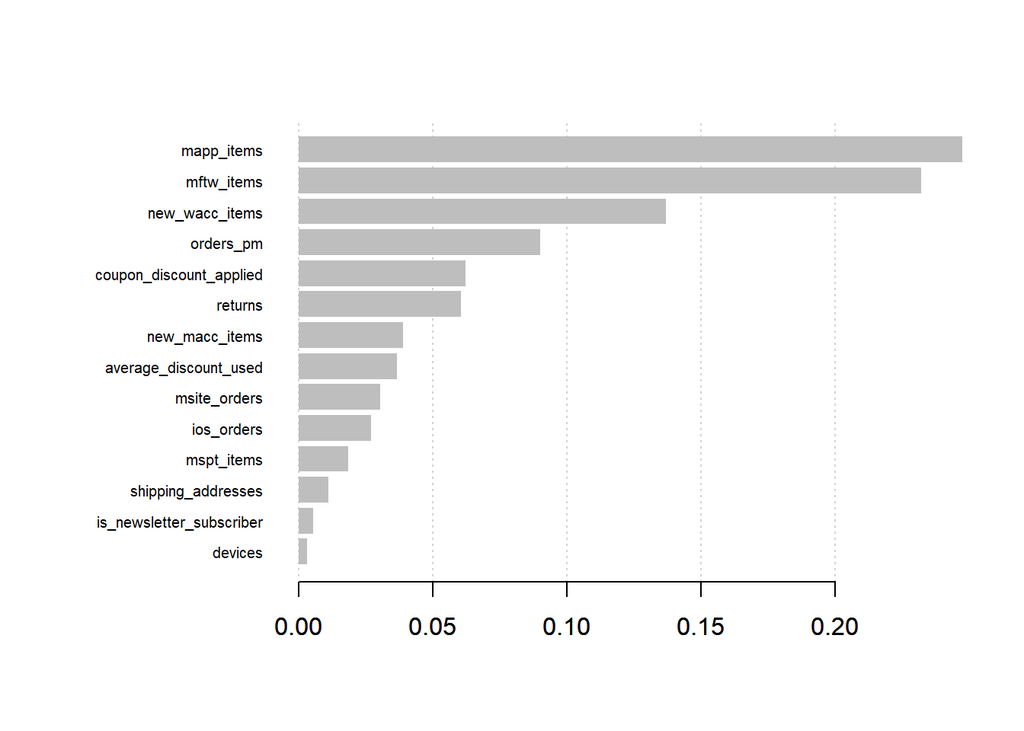

```r
xgb.plot.importance(importance_matrix = importance)
```

The results are sorted by gain and skew heavily towards cart behavior,shopping device and then profile related metrics.

Checking prediction on the holdout data:

```r
valid_df_copy <- select(valid_df,c(devices,mftw_items,mapp_items,returns,new_wacc_items,
                                   new_macc_items,shipping_addresses,orders_pm,mspt_items,
                                   msite_orders,ios_orders,coupon_discount_applied,
                                   is_newsletter_subscriber,average_discount_used,infer_male)) #ensuring only the relevant variables present in the dataset
val_sparse_matrix <- sparse.model.matrix(infer_male ~ ., data = valid_df_copy)[,-1]
pred_xg <- predict(x1, val_sparse_matrix)
pred_xg <- matrix(pred_xg, ncol=2, byrow=TRUE)
valid_df_copy$pred_xg<-max.col(pred_xg, ties.method = "last")-1

confusionMatrix(factor(valid_df_copy$pred_xg),
                factor(valid_df_copy$infer_male),
                mode = "everything")
```

```
## Confusion Matrix and Statistics
##
##           Reference
## Prediction   0   1
##          0 409  10
##          1   9  28
##
##                Accuracy : 0.9583
##                  95% CI : (0.9357, 0.9747)
##     No Information Rate : 0.9167
##     P-Value [Acc > NIR] : 0.0003289
##
##                   Kappa : 0.724
##  Mcnemar's Test P-Value : 1.0000000
##
##             Sensitivity : 0.9785
##             Specificity : 0.7368
##          Pos Pred Value : 0.9761
##          Neg Pred Value : 0.7568
##               Precision : 0.9761
##                  Recall : 0.9785
##                      F1 : 0.9773
##              Prevalence : 0.9167
##          Detection Rate : 0.8969
##    Detection Prevalence : 0.9189
##       Balanced Accuracy : 0.8577
##
##        'Positive' Class : 0
##
```

F1 score is very comparable to RF and RF with SMOTE.

> All machine learning done, time for some performance metrics comparison:

# *Part 6: Model Performance and Accuracy Tradeoffs on Validation/Holdout*

## 5(a): Classification Errors (1-Accuracy)

```r
library(Metrics)
library(pROC)
```

```r
ce(valid_df_copy$infer_male, valid_df_copy$pred_xg)   #Xgboost
```

```
## [1] 0.04166667
```

```r
ce(pred_rf1$infer_male, pred_rf1$pred_rf)             #Tuned Random Forest
```

```
## [1] 0.03289474
```

```r
ce(pred_rf_os$infer_male, pred_rf_os$pred_rf_os)      #Tuned RF with Oversampling
```

```
## [1] 0.05482456
```

```r
detach("package:Metrics", unload=TRUE)
```

Classification error is higher in Xgboost - so even with similar F1, there are loopholes here. The RF is the most stable here.

## 5(b): ROC Receiver Operating Characteristic - Gains chart

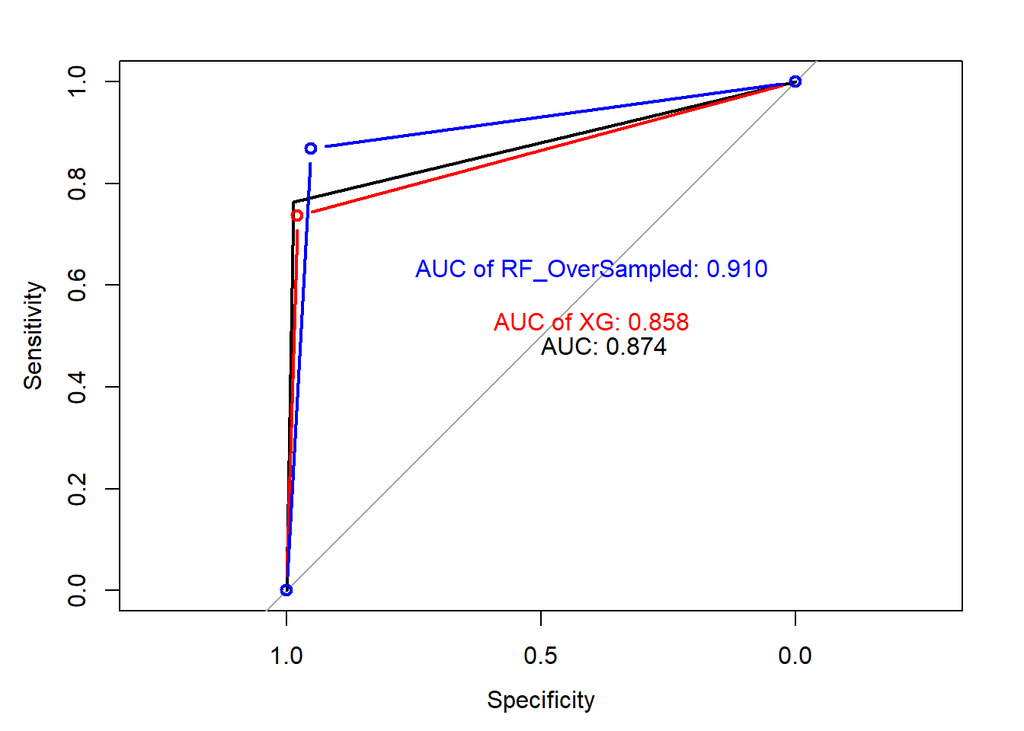

RF with SMOTE shines through here with higher events being captured. Hence, its not going to be an easy battle among these three champions.

Hence, which method we choose depends on how these work on a larger dataset. My personal vote given these results goes to RF as it is most stable and my money will be on the democracy - majority wins generally.

Time to sign off! Cheers.